# MovieLens

Zubair Khan

8/3/2020

```
# please make sure to have the "booktabs" package installed in "MikTek"
```

# Introduction

This report is part of HarvardX’s Capstone project for PH125.9x Data Science course. The purpose of this report is to showcase an operational understanding of R, its toolset and acquired skills in data analytics and mining during the entire course. This report will not just propose a recommandation system but also investigate potential limitations in the dataset and hiddens patterns that will emerge out of it.

The MovieLens 10M dataset is provided by GroupLens, a research lab at the University of Minnesota. The dataset is built from feedback on a rich vairance of users. Through this report we will attempt to predict rating for unseen data. The initial data model approach that was used is to identify hidden patterns by exploiting the genre variable. It was later modified to condition a prediction that yields a RMSE value of lower than 0.86.

## Dataset

The project requirements dicate that the data set is to be downloaded from the following path.

Path = “http://files.grouplens.org/datasets/movielens/ml-10m.zip”

The dataset is then split into the following 2 parts:

- Imported Dataset:
  - edx: contains 90% of the Movielens dataset
  - validation: contains 10% of Movielens dataset

The code required to split the relevant datasets are already provided. Refer to *initialization* section.

# Method

## Penalized least square approach

As the dataset we are working with is already categorical and labeled, my choice of machine learning algorithm was **KMeans**. But due to high computational requiements which I found out in the end, I opted to change the ML algorithm that was lighter in resources. the decision was based on resources available to the evaluators, the course requiement of submitting the result with RMSE and more specifically not modifying the validating dataset, After a bit of searching I have opted to use the PLS ML algorithm. The rationale behind PLS is to approximate the observed data by balancing the conflicts between the exactness to original data and the roughness of fitting data. This on top of searching for a lighter performing algorithm that would not take a long time to complete.

## Findings

One key factor to keep in mind is that the course appoints RMSE grading based on a specific structure which is tied to the **UserID** & **MovieID** columns. As per my findings which will be covered later on, if **RMSE** is calculated without a combination of these two columns the result will not be lower then *0.9000*.

# Initialization

```r
##########################################################
# Create edx set, validation set (final hold-out test set)
##########################################################

# Note: this process could take a couple of minutes

if(!require(tidyverse)) install.packages("tidyverse", repos = "http://cran.us.r-project.org")
if(!require(caret)) install.packages("caret", repos = "http://cran.us.r-project.org")
if(!require(data.table)) install.packages("data.table", repos = "http://cran.us.r-project.org")

# MovieLens 10M dataset:
# https://grouplens.org/datasets/movielens/10m/
# http://files.grouplens.org/datasets/movielens/ml-10m.zip

dl <- tempfile()
download.file("http://files.grouplens.org/datasets/movielens/ml-10m.zip", dl)

ratings <- fread(text = gsub("::", "\t", readLines(unzip(dl, "ml-10M100K/ratings.dat"))),
                 col.names = c("userId", "movieId", "rating", "timestamp"))

movies <- str_split_fixed(readLines(unzip(dl, "ml-10M100K/movies.dat")), "\\::", 3)
colnames(movies) <- c("movieId", "title", "genres")

# if using R 3.6 or earlier
movies <- as.data.frame(movies) %>% mutate(movieId = as.numeric(levels(movieId))[movieId],
                                           title = as.character(title),
                                           genres = as.character(genres))
# if using R 4.0 or later
#movies <- as.data.frame(movies) %>% mutate(movieId = as.numeric(movieId),
 #                                          title = as.character(title),
  #                                         genres = as.character(genres))

movielens <- left_join(ratings, movies, by = "movieId")

# Validation set will be 10% of MovieLens data
set.seed(1)
# if using R 3.5 or earlier, use `set.seed(1)` instead
test_index <- createDataPartition(y = movielens$rating, times = 1, p = 0.1, list = FALSE)
edx <- movielens[-test_index,]
temp <- movielens[test_index,]

# Make sure userId and movieId in validation set are also in edx set
validation <- temp %>%
  semi_join(edx, by = "movieId") %>%
  semi_join(edx, by = "userId")

# Add rows removed from validation set back into edx set
removed <- anti_join(temp, validation)
edx <- rbind(edx, removed)

rm(dl, ratings, movies, test_index, temp, movielens, removed)
```

Once the required data is loaded into the environment we will begin our investigation process.

## Goal

While examining the **Dataset** we observer that the **Genre** variable is a composit of multiple genre categories. Prior to splitting the dataframe we need to consider what is required of it. We can look at splitting it into a new line entry for each category and then using that as our baseline category and proceed with identifying patterns. I have opted to construct a data matrix from the genre section and then populate it with boolean values if it matches a certain category

One thing to note is that, Movies that just have one genre only should be considered as anomalies or errors and should be excluded from our final dataset as in real world scenerio they are a combination of genres. We will proceed as it is for now.

# Data Exploration & Analytics

## Libraries

Loading the required libraries

```r
#Working with edx library
if(!require(ggplot2)) install.packages("ggplot2")
if(!require(anytime)) install.packages("anytime")
if(!require(sjmisc)) install.packages("sjmisc")
if(!require(scales)) install.packages("scales")
if(!require(dplyr)) install.packages("dplyr")
if(!require(tinytex)) install.packages("tinytex")

library(ggplot2)
library(anytime)
library(sjmisc)
library(scales)
library(dplyr)
library(ggplot2)
library(formattable)
library(tinytex)
```

## Examining Dataset

```
##    userId movieId rating timestamp                title
## 1:      1     122      5 838985046     Boomerang (1992)
## 2:      1     185      5 838983525      Net, The (1995)
## 3:      1     231      5 838983392 Dumb & Dumber (1994)
## 4:      1     292      5 838983421      Outbreak (1995)
## 5:      1     316      5 838983392      Stargate (1994)
##                          genres
## 1:               Comedy|Romance
## 2:        Action|Crime|Thriller
## 3:                       Comedy
## 4: Action|Drama|Sci-Fi|Thriller
## 5:      Action|Adventure|Sci-Fi
```

```
##      userId         movieId          rating        timestamp
##  Min.   :    1   Min.   :    1   Min.   :0.500   Min.   :7.897e+08
##  1st Qu.:18122   1st Qu.:  648   1st Qu.:3.000   1st Qu.:9.468e+08
##  Median :35743   Median : 1834   Median :4.000   Median :1.035e+09
##  Mean   :35869   Mean   : 4120   Mean   :3.512   Mean   :1.033e+09
##  3rd Qu.:53602   3rd Qu.: 3624   3rd Qu.:4.000   3rd Qu.:1.127e+09
##  Max.   :71567   Max.   :65133   Max.   :5.000   Max.   :1.231e+09
##     title              genres
##  Length:9000061     Length:9000061
##  Class :character   Class :character
##  Mode  :character   Mode  :character
##
##
##
```

```
## Classes 'data.table' and 'data.frame':   9000061 obs. of  6 variables:
##  $ userId   : int  1 1 1 1 1 1 1 1 1 1 ...
##  $ movieId  : num  122 185 231 292 316 329 355 356 362 364 ...
##  $ rating   : num  5 5 5 5 5 5 5 5 5 5 ...
##  $ timestamp: int  838985046 838983525 838983392 838983421 838983392 838983392 838984474 838983653 838984885 838983707 ...
##  $ title    : chr  "Boomerang (1992)" "Net, The (1995)" "Dumb & Dumber (1994)" "Outbreak (1995)" ...
##  $ genres   : chr  "Comedy|Romance" "Action|Crime|Thriller" "Comedy" "Action|Drama|Sci-Fi|Thriller" ...
##  - attr(*, ".internal.selfref")=<externalptr>
```

The EDX dataset contains 9000061 and 6 attributes. There are a total of 69878 **Users** accounts and 10677 **Movies** titles being represented in the dataframe. The titles column hold movie release details. The genre column has genre’s piped along side various genre categories.

```
##  [1] "Comedy"             "Romance"            "Action"
##  [4] "Crime"              "Thriller"           "Drama"
##  [7] "Sci-Fi"             "Adventure"          "Children"
## [10] "Fantasy"            "War"                "Animation"
## [13] "Musical"            "Western"            "Mystery"
## [16] "Film-Noir"          "Horror"             "Documentary"
## [19] "IMAX"               "(no genres listed)"
```

Looking at the **genres** variable, we can identify that there are a total of 20 genres with movie titles holding a maximum of 8. Splitting the genre column and building a matrix that will hold boolean value if movie title belongs to that genre. This Data Martix will later assist us in further data categorization and explorations.

The below table represents the genre distribution accross various movie titles. Higher number represents movies created within the dataset time frame that hold specified genre.

```r
#Genres in descending order
edx_filter %>% group_by(genres) %>% summarize(count = n()) %>%
  arrange(desc(count))
```

```
## # A tibble: 20 x 2
##    genres               count
##    <chr>                <int>
##  1 Drama              3909401
##  2 Comedy             3541284
##  3 Action             2560649
##  4 Thriller           2325349
##  5 Adventure          1908692
##  6 Romance            1712232
##  7 Sci-Fi             1341750
##  8 Crime              1326917
##  9 Fantasy             925624
## 10 Children            737851
## 11 Horror              691407
## 12 Mystery             567865
## 13 War                 511330
## 14 Animation           467220
## 15 Musical             432960
## 16 Western             189234
## 17 Film-Noir           118394
## 18 Documentary          93252
## 19 IMAX                  8190
## 20 (no genres listed)       6
```

Futher data exploration is required. To create the data matrix mention above, we will create a new dataset and migrate only relevant columns in it. Then based on genre count as calculated above, we will add relevant columns in the same sequence.

```
##  [1] "1992" "1995" "1994" "1993" "1990" "1991" "1937" "1970" "1977" "1996"
## [11] "1972" "1971" "1989" "1974" "1967" "1997" "1985" "2000" "1982" "2001"
## [21] "2002" "2003" "2004" "2005" "1976" "1958" "1942" "1939" "1941" "1950"
## [31] "1951" "1979" "1955" "1962" "1984" "1980" "1988" "1975" "1987" "1981"
## [41] "1969" "1998" "1999" "1986" "1952" "1959" "1946" "1944" "1940" "1954"
## [51] "1983" "1949" "1960" "1973" "1948" "1933" "1931" "1963" "1922" "1943"
## [61] "1956" "1957" "1953" "1965" "1978" "1964" "1968" "1966" "1961" "1935"
## [71] "1938" "2006" "2007" "1932" "2008" "1934" "1945" "1936" "1947" "1927"
## [81] "1925" "1930" "1929" "1923" "1928" "1921" "1926" "1915" "1924" "1916"
## [91] "1917" "1918" "1920" "1919"
```

The final data set contains a better categorization of genre variable. Although this has added more columns in our dataset, it will allow us to perform better filtering and data exploration. Unfortunately, I am at a press of time for submission and need to do a bit more research on using ML with matrix’s. We will proceed with RMSE calculations without it.

Edx_Final sample Dataset

| userId | movieId | rating | title | Drama | Comedy | Action | Thriller | Adventure | Romance | SciFi | Crime | Fantasy | Children | Horror | Mystery | War | Animation | Musical | Western | FilmNoir | Documentary | IMAX | NoGenres | RelYear | Year |
| --- | --- | --- | --- | --- | --- | --- | --- | --- | --- | --- | --- | --- | --- | --- | --- | --- | --- | --- | --- | --- | --- | --- | --- | --- | --- |
| 1 | 122 | 5 | Boomerang (1992) | FALSE | TRUE | FALSE | FALSE | FALSE | TRUE | FALSE | FALSE | FALSE | FALSE | FALSE | FALSE | FALSE | FALSE | FALSE | FALSE | FALSE | FALSE | FALSE | FALSE | 1992 | 1996 |
| 1 | 185 | 5 | Net, The (1995) | FALSE | FALSE | TRUE | TRUE | FALSE | FALSE | FALSE | TRUE | FALSE | FALSE | FALSE | FALSE | FALSE | FALSE | FALSE | FALSE | FALSE | FALSE | FALSE | FALSE | 1995 | 1996 |
| 1 | 231 | 5 | Dumb & Dumber (1994) | FALSE | TRUE | FALSE | FALSE | FALSE | FALSE | FALSE | FALSE | FALSE | FALSE | FALSE | FALSE | FALSE | FALSE | FALSE | FALSE | FALSE | FALSE | FALSE | FALSE | 1994 | 1996 |
| 1 | 292 | 5 | Outbreak (1995) | TRUE | FALSE | TRUE | TRUE | FALSE | FALSE | TRUE | FALSE | FALSE | FALSE | FALSE | FALSE | FALSE | FALSE | FALSE | FALSE | FALSE | FALSE | FALSE | FALSE | 1995 | 1996 |
| 1 | 316 | 5 | Stargate (1994) | FALSE | FALSE | TRUE | FALSE | TRUE | FALSE | TRUE | FALSE | FALSE | FALSE | FALSE | FALSE | FALSE | FALSE | FALSE | FALSE | FALSE | FALSE | FALSE | FALSE | 1994 | 1996 |
| 1 | 329 | 5 | Star Trek: Generations (1994) | TRUE | FALSE | TRUE | FALSE | TRUE | FALSE | TRUE | FALSE | FALSE | FALSE | FALSE | FALSE | FALSE | FALSE | FALSE | FALSE | FALSE | FALSE | FALSE | FALSE | 1994 | 1996 |

Lets examine the distribution of ratings to get a clear understanding of how users have rated titles.

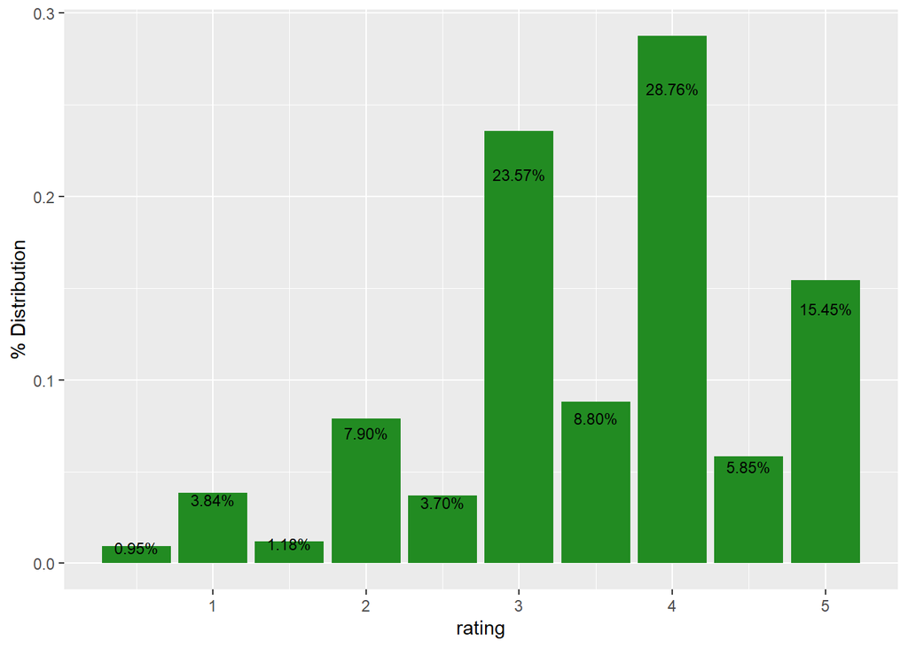

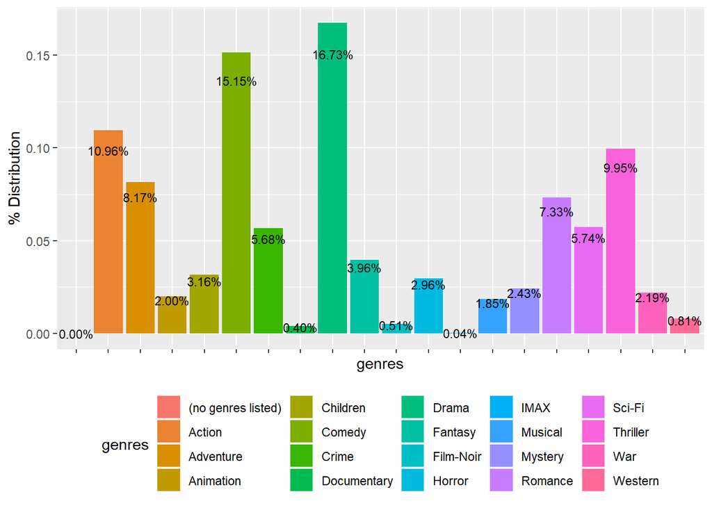

Lets plot the user distribution to get an perspective of how users are distributed based on their amount of rating feedback.

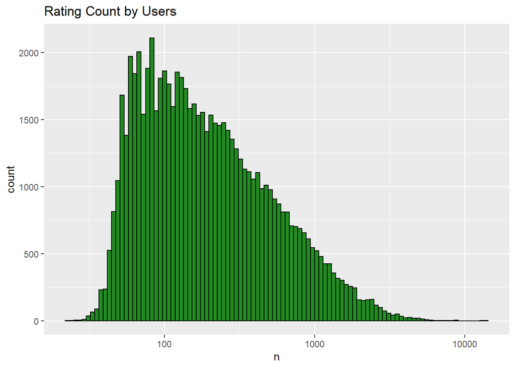

The above chart indicated that user rating is not evenly distributed. Rating count has had substantial growth from 50 and then a gradual decrease post 100.

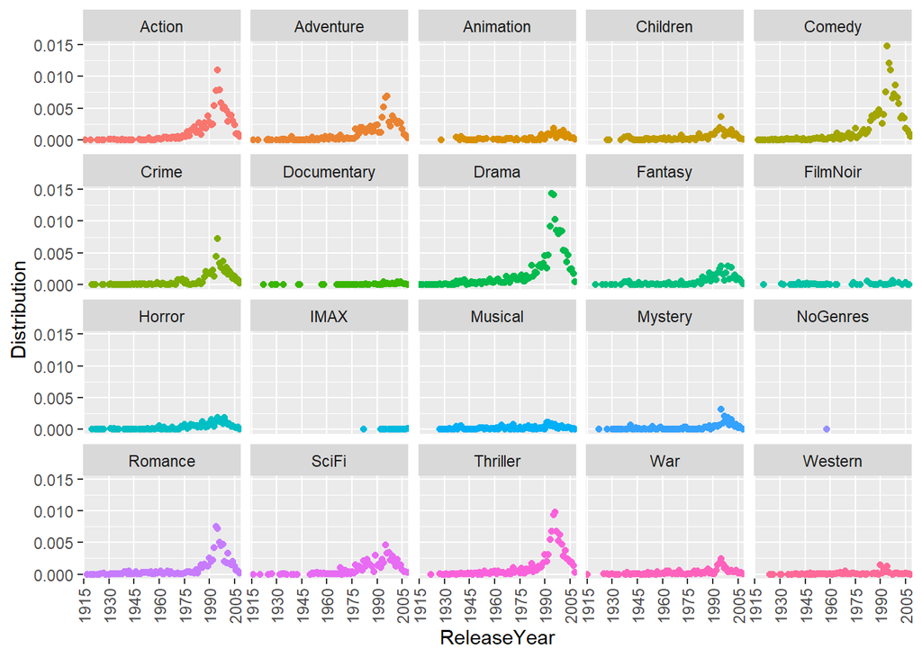

Through out the timeline **Action**, **Adventure**, **Comedy**, **Drama**, ***Romance** and **Thriler** have sustained an overall strong presence. It can be stipulated that movies produced with either of the genres or combination of genre’s will sustain a strong user attention.

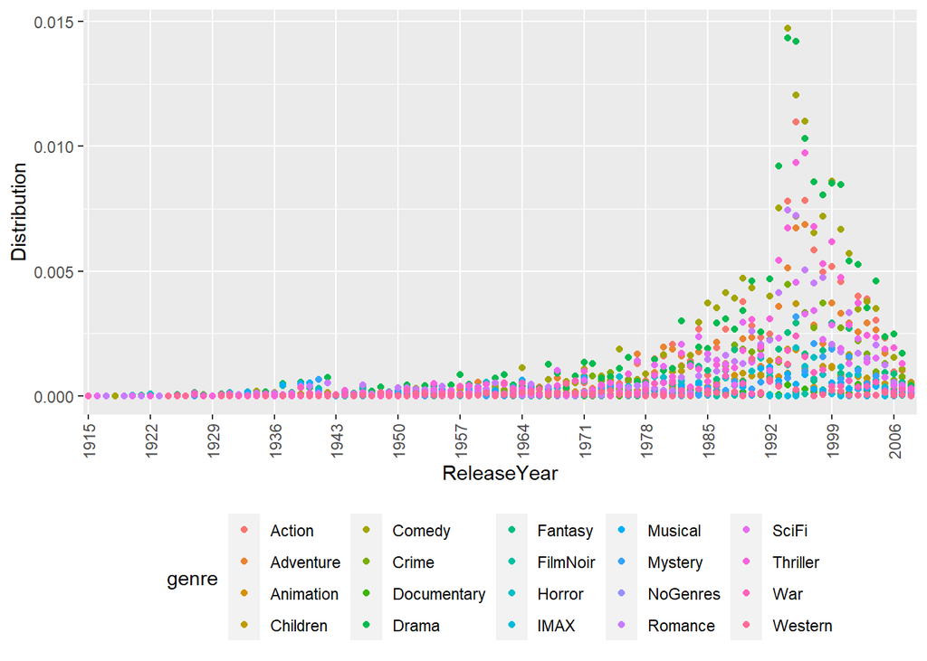

Reviewing the above chart we can stipulate that there is a substantial increase in ratings in 1990’s. This is later identified to be corelated with the year the introduction of the rating system.

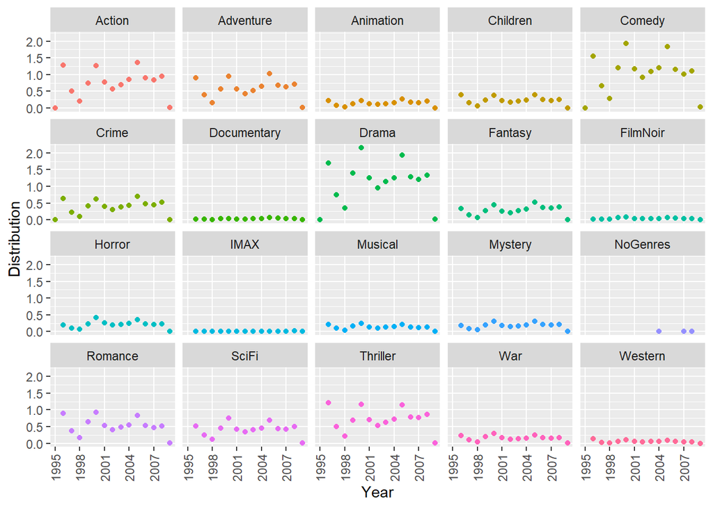

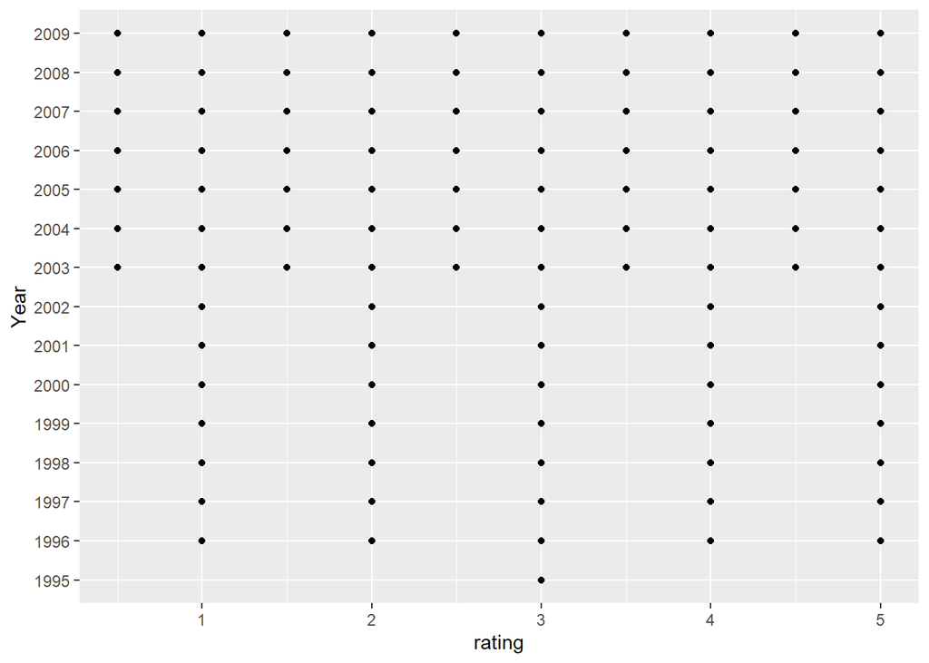

Looking at the relationship between rating and the year it was captured we notice that the half ratings were absent prior to 2003. The dataset is not coherent in regards to the rating variable. This can be corrected by rounding up the half variances. As the dataset has a combination of two unevenly-sized distribution, We will continue as is and exclude the rating variable from our RMSE calculation.

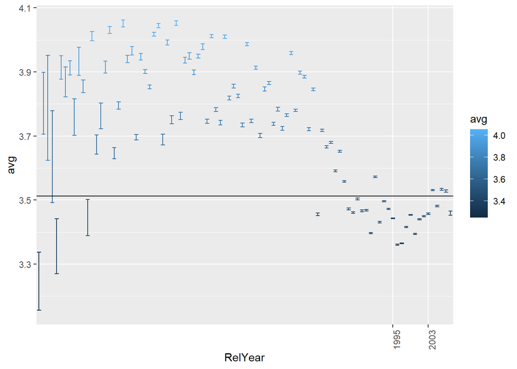

Looking at the above distribution we conclude that older movie titles have had a better rating as compared to newer titles. This can be contributed to the fact that older movies has less count but better rating and newer movies have tighter variability and are closer to the mean. From the data represented in **Release Year** chart we can conclude this is directly related to amount of ratings captured.

#Results

As stipulated in the Method section I will be using the PLS ML algorithm to finetune my RMSE results. My system configurations are as follows: + CPU: Core i5 - 2.4Ghz + RAM: 16GB

```r
#Lambda is set to the specified sequence after repeated testes yealded no benefit to changes in it.
lambda <- seq(0, 3, 0.25)

RMSE <- function(true_ratings, predicted_ratings){
  sqrt(mean((true_ratings - predicted_ratings)^2))
}
```

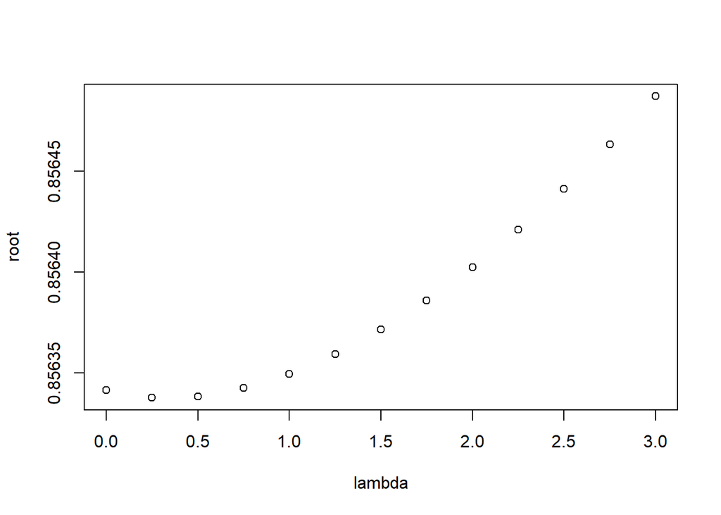

```r
root <- sapply(lambda, function(l){
  mu <- mean(edx_final$rating)
  AdjustG <- edx_final %>% group_by(movieId) %>% summarise(AdjustG = sum(rating - mu)/(n()+l))

  AdjustU <- edx_final %>% left_join(AdjustG, by="movieId") %>% group_by(userId) %>%
    summarise(AdjustU = sum(rating - AdjustG - mu)/(n()+l))

  AdjustM <- edx_final %>% left_join(AdjustG, by="movieId") %>%
    left_join(AdjustU, by="userId") %>% group_by(RelYear) %>%
    summarise(AdjustM = sum(rating - AdjustG -AdjustU - mu)/(n()+l))

  prediction <- edx_final %>% left_join(AdjustG, by = "movieId") %>% left_join(AdjustU, by = "userId") %>%
    left_join(AdjustM, by = "RelYear") %>%
    mutate(predict = AdjustG + AdjustU +AdjustM + mu) %>% .$predict
  return(RMSE(prediction, edx_final$rating))
})

plot(lambda, root)
```

```r
min(root)
```

```
## [1] 0.8563378
```

```r
lambda[which.min(root)]
```

```
## [1] 0.25
```

```r
lambda <- lambda[which.min(root)]

#we need to modify the validation set to include Release year

#dim(validation)
#head(validation)

RelYear <- substr(validation$title, nchar(validation$title)-4,nchar(validation$title)-1) #Extract release year of Title
validation$RelYear <- as.factor(RelYear)

Fdate <- anydate(validation$timestamp)
validation$Year <- as.factor(format(Fdate, "%Y")) #Creating a column that will contain Year


root <- sapply(lambda, function(l){
  mu <- mean(validation$rating)
  AdjustG <- validation %>% group_by(movieId) %>% summarise(AdjustG = sum(rating - mu)/(n()+l))

  AdjustU <- validation %>% left_join(AdjustG, by="movieId") %>% group_by(userId) %>%
    summarise(AdjustU = sum(rating - AdjustG - mu)/(n()+l))

  AdjustM <- validation %>% left_join(AdjustG, by="movieId") %>%
    left_join(AdjustU, by="userId") %>% group_by(RelYear) %>%
    summarise(AdjustM = sum(rating - AdjustG -AdjustU - mu)/(n()+l))

  prediction <- validation %>% left_join(AdjustG, by = "movieId") %>% left_join(AdjustU, by = "userId") %>%
    left_join(AdjustM, by = "RelYear") %>%
    mutate(predict = AdjustG + AdjustU +AdjustM + mu) %>% .$predict
  return(RMSE(prediction, validation$rating))
})

write.csv(validation, file = "submission.csv", row.names = FALSE)
```